# unit-4-correlation-regression

```python
import pandas as pd
```

```python
dfpop=pd.read_csv("Global_Population.csv")
dfpop.head(10)
```

|  | Country Name | Country Code | Series Name | Series Code | 1960 | 1961 | 1962 | 1963 | 1964 | 1965 | ... | 2012 | 2013 | 2014 | 2015 | 2016 | 2017 | 2018 | 2019 | 2020 | 2021 |
| --- | --- | --- | --- | --- | --- | --- | --- | --- | --- | --- | --- | --- | --- | --- | --- | --- | --- | --- | --- | --- | --- |
| 0 | Aruba | ABW | Population, total | SP.POP.TOTL | 54211 | 55438 | 56225 | 56695 | 57032 | 57360 | ... | 102560 | 103159 | 103774 | 104341 | 104872 | 105366 | 105845 | 106314 | NaN | NaN |
| 1 | Afghanistan | AFG | Population, total | SP.POP.TOTL | 8996967 | 9169406 | 9351442 | 9543200 | 9744772 | 9956318 | ... | 31161378 | 32269592 | 33370804 | 34413603 | 35383028 | 36296111 | 37171922 | 38041757 | 38928341 | 39835000 |
| 2 | Africa Eastern and Southern | AFE | Population, total | SP.POP.TOTL | 130836765 | 134159786 | 137614644 | 141202036 | 144920186 | 148769974 | ... | 547482863 | 562601578 | 578075373 | 593871847 | 609978946 | 626392880 | 643090131 | 660046272 | 677243299 | 694664000 |
| 3 | Africa Western and Central | AFW | Population, total | SP.POP.TOTL | 96396419 | 98407221 | 100506960 | 102691339 | 104953470 | 107289875 | ... | 370243017 | 380437896 | 390882979 | 401586651 | 412551299 | 423769930 | 435229381 | 446911598 | 458803476 | 470898000 |
| 4 | Albania | ALB | Population, total | SP.POP.TOTL | 1608800 | 1659800 | 1711319 | 1762621 | 1814135 | 1864791 | ... | 2900401 | 2895092 | 2889104 | 2880703 | 2876101 | 2873457 | 2866376 | 2854191 | 2837743 | 2832000 |
| 5 | Algeria | DZA | Population, total | SP.POP.TOTL | 11057864 | 11336336 | 11619828 | 11912800 | 12221675 | 12550880 | ... | 37383899 | 38140135 | 38923688 | 39728020 | 40551398 | 41389174 | 42228415 | 43053054 | 43851043 | 44617000 |
| 6 | American Samoa | ASM | Population, total | SP.POP.TOTL | 20127 | 20605 | 21246 | 22029 | 22850 | 23675 | ... | 55669 | 55717 | 55791 | 55806 | 55739 | 55617 | 55461 | 55312 | 55197 | 55000 |
| 7 | Andorra | AND | Population, total | SP.POP.TOTL | 13410 | 14378 | 15379 | 16407 | 17466 | 18542 | ... | 82427 | 80770 | 79213 | 77993 | 77295 | 76997 | 77008 | 77146 | 77265 | 77000 |
| 8 | Angola | AGO | Population, total | SP.POP.TOTL | 5454938 | 5531451 | 5608499 | 5679409 | 5734995 | 5770573 | ... | 25107925 | 26015786 | 26941773 | 27884380 | 28842482 | 29816769 | 30809787 | 31825299 | 32866268 | 33934000 |
| 9 | Antigua and Barbuda | ATG | Population, total | SP.POP.TOTL | 54132 | 55005 | 55849 | 56701 | 57641 | 58699 | ... | 90407 | 91510 | 92562 | 93571 | 94520 | 95425 | 96282 | 97115 | 97928 | 99000 |

10 rows × 66 columns

```python
dfgdp=pd.read_csv("Global_GDP.csv")
dfgdp.head(10)
```

|  | Country Name | Country Code | Indicator Name | Indicator Code | 1960 | 1961 | 1962 | 1963 | 1964 | 1965 | ... | 2011 | 2012 | 2013 | 2014 | 2015 | 2016 | 2017 | 2018 | 2019 | 2020 |
| --- | --- | --- | --- | --- | --- | --- | --- | --- | --- | --- | --- | --- | --- | --- | --- | --- | --- | --- | --- | --- | --- |
| 0 | Aruba | ABW | GDP (current US$) | NY.GDP.MKTP.CD | NaN | NaN | NaN | NaN | NaN | NaN | ... | 2.549721e+09 | 2.534637e+09 | 2.727850e+09 | 2.790849e+09 | 2.962905e+09 | 2.983637e+09 | 3.092430e+09 | 3.202189e+09 | NaN | NaN |
| 1 | Africa Eastern and Southern | AFE | GDP (current US$) | NY.GDP.MKTP.CD | 1.929944e+10 | 1.970954e+10 | 2.147872e+10 | 2.571501e+10 | 2.351080e+10 | 2.679160e+10 | ... | 9.427110e+11 | 9.498490e+11 | 9.635600e+11 | 9.837490e+11 | 9.186470e+11 | 8.720230e+11 | 9.842560e+11 | 1.011720e+12 | 1.008380e+12 | 9.188150e+11 |
| 2 | Afghanistan | AFG | GDP (current US$) | NY.GDP.MKTP.CD | 5.377778e+08 | 5.488889e+08 | 5.466667e+08 | 7.511112e+08 | 8.000000e+08 | 1.006667e+09 | ... | 1.780511e+10 | 1.990732e+10 | 2.014640e+10 | 2.049713e+10 | 1.913421e+10 | 1.811656e+10 | 1.875347e+10 | 1.805323e+10 | 1.879945e+10 | 2.011614e+10 |
| 3 | Africa Western and Central | AFW | GDP (current US$) | NY.GDP.MKTP.CD | 1.040428e+10 | 1.112805e+10 | 1.194335e+10 | 1.267652e+10 | 1.383858e+10 | 1.486247e+10 | ... | 6.709630e+11 | 7.275710e+11 | 8.207880e+11 | 8.514870e+11 | 7.607300e+11 | 6.905430e+11 | 6.837420e+11 | 7.416920e+11 | 7.945720e+11 | 7.845880e+11 |
| 4 | Angola | AGO | GDP (current US$) | NY.GDP.MKTP.CD | NaN | NaN | NaN | NaN | NaN | NaN | ... | 1.117900e+11 | 1.280530e+11 | 1.367100e+11 | 1.457120e+11 | 1.161940e+11 | 1.011240e+11 | 1.221240e+11 | 1.013530e+11 | 8.941719e+10 | 5.837598e+10 |
| 5 | Albania | ALB | GDP (current US$) | NY.GDP.MKTP.CD | NaN | NaN | NaN | NaN | NaN | NaN | ... | 1.289076e+10 | 1.231983e+10 | 1.277622e+10 | 1.322815e+10 | 1.138685e+10 | 1.186120e+10 | 1.301969e+10 | 1.515643e+10 | 1.540024e+10 | 1.488763e+10 |
| 6 | Andorra | AND | GDP (current US$) | NY.GDP.MKTP.CD | NaN | NaN | NaN | NaN | NaN | NaN | ... | 3.629204e+09 | 3.188809e+09 | 3.193704e+09 | 3.271808e+09 | 2.789870e+09 | 2.896679e+09 | 3.000181e+09 | 3.218316e+09 | 3.155065e+09 | NaN |
| 7 | Arab World | ARB | GDP (current US$) | NY.GDP.MKTP.CD | NaN | NaN | NaN | NaN | NaN | NaN | ... | 2.491550e+12 | 2.728990e+12 | 2.787520e+12 | 2.818610e+12 | 2.452010e+12 | 2.400960e+12 | 2.455070e+12 | 2.717930e+12 | 2.763200e+12 | 2.436290e+12 |
| 8 | United Arab Emirates | ARE | GDP (current US$) | NY.GDP.MKTP.CD | NaN | NaN | NaN | NaN | NaN | NaN | ... | 3.506660e+11 | 3.745910e+11 | 3.901080e+11 | 4.031370e+11 | 3.581350e+11 | 3.570450e+11 | 3.856060e+11 | 4.222150e+11 | 4.172160e+11 | 3.588690e+11 |
| 9 | Argentina | ARG | GDP (current US$) | NY.GDP.MKTP.CD | NaN | NaN | 2.445060e+10 | 1.827212e+10 | 2.560525e+10 | 2.834471e+10 | ... | 5.301630e+11 | 5.459820e+11 | 5.520250e+11 | 5.263200e+11 | 5.947490e+11 | 5.575310e+11 | 6.436290e+11 | 5.248200e+11 | 4.519320e+11 | 3.892880e+11 |

10 rows × 65 columns

# Removing Missing Values from both datasets

When calculating a correlation between two variables, the calculation typically involves multiplying or summing values from both variables for each observation. If an observation has a missing value in either of the variables we are trying to correlate, that observation cannot be included in the calculation.

Most statistical software and libraries (like pandas in Python) will automatically exclude rows with missing values when computing correlations. However, explicitly removing missing values beforehand gives you more control and transparency over which data is being used. It also helps avoid potential errors or unexpected results that can occur when working with functions that might not handle missing values gracefully.

Essentially, to get an accurate correlation coefficient, we need complete pairs of data for the variables we are analyzing. Removing missing values ensures that our correlation calculation is based only on these complete pairs.

```python
dfpop_cleaned = dfpop.dropna()
dfgdp_cleaned = dfgdp.dropna()

print("Shape of dfpop after dropping missing values:", dfpop_cleaned.shape)
print("Shape of dfgdp after dropping missing values:", dfgdp_cleaned.shape)
```

```
Shape of dfpop after dropping missing values: (266, 66)
Shape of dfgdp after dropping missing values: (119, 65)
```

# Task

## Calculate per capita gdp

### Subtask:

Divide the GDP by the population for each country and year in the cleaned dataframes to get per capita GDP.

**Reasoning**: Identify the year columns in both dataframes, align the dataframes by country code, and then calculate the per capita GDP for each year by dividing GDP by population. Create a new dataframe to store the results.

```python
# Identify year columns (assuming year columns are numeric strings from 1960 to 2021)
year_cols_pop = [col for col in dfpop_cleaned.columns if col.isdigit() and 1960 <= int(col) <= 2021]
year_cols_gdp = [col for col in dfgdp_cleaned.columns if col.isdigit() and 1960 <= int(col) <= 2021]

# Find common years
common_years = list(set(year_cols_pop) & set(year_cols_gdp))
common_years.sort()

# Select only common year columns and country information from both dataframes
dfpop_years = dfpop_cleaned[['Country Name', 'Country Code'] + common_years].copy()
dfgdp_years = dfgdp_cleaned[['Country Name', 'Country Code'] + common_years].copy()

# Convert year columns to numeric, coercing errors to NaN
for year in common_years:
    dfpop_years[year] = pd.to_numeric(dfpop_years[year], errors='coerce')
    dfgdp_years[year] = pd.to_numeric(dfgdp_years[year], errors='coerce')

# Merge dataframes on 'Country Code' to ensure country alignment
merged_df = pd.merge(dfgdp_years, dfpop_years, on='Country Code', suffixes=('_gdp', '_pop'))

# Calculate per capita GDP for each year
df_per_capita_gdp = pd.DataFrame()
df_per_capita_gdp['Country Name'] = merged_df['Country Name_gdp']
df_per_capita_gdp['Country Code'] = merged_df['Country Code']

for year in common_years:
    gdp_col = year + '_gdp'
    pop_col = year + '_pop'
    # Handle potential division by zero or NaN in population
    df_per_capita_gdp[year] = merged_df[gdp_col] / merged_df[pop_col]

# Display the first few rows of the resulting dataframe
display(df_per_capita_gdp.head())
```

|  | Country Name | Country Code | 1960 | 1961 | 1962 | 1963 | 1964 | 1965 | 1966 | 1967 | ... | 2011 | 2012 | 2013 | 2014 | 2015 | 2016 | 2017 | 2018 | 2019 | 2020 |
| --- | --- | --- | --- | --- | --- | --- | --- | --- | --- | --- | --- | --- | --- | --- | --- | --- | --- | --- | --- | --- | --- |
| 0 | Africa Eastern and Southern | AFE | 147.507808 | 146.910907 | 156.078705 | 182.115000 | 162.232750 | 180.087426 | 190.710482 | 192.201110 | ... | 1769.483913 | 1734.938323 | 1712.686273 | 1701.765974 | 1546.877503 | 1429.595244 | 1571.307771 | 1573.216492 | 1527.741376 | 1356.698547 |
| 1 | Africa Western and Central | AFW | 107.932233 | 113.081647 | 118.831107 | 123.442888 | 131.854402 | 138.526332 | 144.326212 | 128.582470 | ... | 1862.309512 | 1965.117414 | 2157.482229 | 2178.368069 | 1894.310974 | 1673.835476 | 1613.474557 | 1704.140466 | 1777.917610 | 1710.074228 |
| 2 | Australia | AUS | 1810.619230 | 1877.616638 | 1854.656834 | 1967.116537 | 2131.377948 | 2281.098797 | 2343.995290 | 2580.271096 | ... | 62574.238953 | 68027.905117 | 68156.831882 | 62511.485287 | 56706.847646 | 49881.965980 | 53934.133435 | 57180.796558 | 54875.186989 | 51692.991809 |
| 3 | Austria | AUT | 935.460427 | 1031.815004 | 1087.834243 | 1167.000532 | 1269.412583 | 1374.532140 | 1486.968606 | 1569.667183 | ... | 51374.921455 | 48567.667510 | 50716.742555 | 51717.480526 | 44178.097606 | 45276.872144 | 47311.949692 | 51461.446673 | 50114.415445 | 48586.748875 |
| 4 | Burundi | BDI | 70.051910 | 71.167188 | 73.435331 | 78.514621 | 86.161550 | 51.381881 | 52.182552 | 54.806443 | ... | 249.577979 | 252.358871 | 256.975653 | 274.857836 | 305.549652 | 260.565221 | 253.826354 | 238.783467 | 228.213589 | 238.990726 |

5 rows × 63 columns

## Filter by year

### Subtask:

Filter both the population and per capita GDP dataframes to include only the years from 2001 to 2021.

**Reasoning**: Filter the dataframes to include only the years from 2001 to 2021 and the country information.

```python
print("Columns in dfpop_years:", dfpop_years.columns.tolist())
print("Columns in df_per_capita_gdp:", df_per_capita_gdp.columns.tolist())
```

```
Columns in dfpop_years: ['Country Name', 'Country Code', '1960', '1961', '1962', '1963', '1964', '1965', '1966', '1967', '1968', '1969', '1970', '1971', '1972', '1973', '1974', '1975', '1976', '1977', '1978', '1979', '1980', '1981', '1982', '1983', '1984', '1985', '1986', '1987', '1988', '1989', '19…
Columns in df_per_capita_gdp: ['Country Name', 'Country Code', '1960', '1961', '1962', '1963', '1964', '1965', '1966', '1967', '1968', '1969', '1970', '1971', '1972', '1973', '1974', '1975', '1976', '1977', '1978', '1979', '1980', '1981', '1982', '1983', '1984', '1985', '1986', '1987', '1988', '1989…
```

**Reasoning**: The columns show that the data for years go up to 2020, not 2021. I will adjust the year range accordingly and filter the dataframes.

```python
year_cols_2001_2020 = [str(year) for year in range(2001, 2021)]

dfpop_filtered = dfpop_years[['Country Name', 'Country Code'] + year_cols_2001_2020].copy()
df_per_capita_gdp_filtered = df_per_capita_gdp[['Country Name', 'Country Code'] + year_cols_2001_2020].copy()

display(dfpop_filtered.head())
display(df_per_capita_gdp_filtered.head())
```

|  | Country Name | Country Code | 2001 | 2002 | 2003 | 2004 | 2005 | 2006 | 2007 | 2008 | ... | 2011 | 2012 | 2013 | 2014 | 2015 | 2016 | 2017 | 2018 | 2019 | 2020 |
| --- | --- | --- | --- | --- | --- | --- | --- | --- | --- | --- | --- | --- | --- | --- | --- | --- | --- | --- | --- | --- | --- |
| 1 | Afghanistan | AFG | 21606992.0 | 22600774.0 | 23680871.0 | 24726689.0 | 25654274.0 | 26433058.0 | 27100542.0 | 27722281.0 | ... | 30117411.0 | 31161378.0 | 32269592.0 | 33370804.0 | 34413603.0 | 35383028.0 | 36296111.0 | 37171922.0 | 38041757.0 | 38928341.0 |
| 2 | Africa Eastern and Southern | AFE | 408522129.0 | 419223717.0 | 430246635.0 | 441630149.0 | 453404076.0 | 465581372.0 | 478166911.0 | 491173160.0 | ... | 532760424.0 | 547482863.0 | 562601578.0 | 578075373.0 | 593871847.0 | 609978946.0 | 626392880.0 | 643090131.0 | 660046272.0 | 677243299.0 |
| 3 | Africa Western and Central | AFW | 274433894.0 | 281842480.0 | 289469530.0 | 297353098.0 | 305520588.0 | 313985474.0 | 322741656.0 | 331772330.0 | ... | 360285439.0 | 370243017.0 | 380437896.0 | 390882979.0 | 401586651.0 | 412551299.0 | 423769930.0 | 435229381.0 | 446911598.0 | 458803476.0 |
| 4 | Albania | ALB | 3060173.0 | 3051010.0 | 3039616.0 | 3026939.0 | 3011487.0 | 2992547.0 | 2970017.0 | 2947314.0 | ... | 2905195.0 | 2900401.0 | 2895092.0 | 2889104.0 | 2880703.0 | 2876101.0 | 2873457.0 | 2866376.0 | 2854191.0 | 2837743.0 |
| 5 | Algeria | DZA | 31451513.0 | 31855110.0 | 32264159.0 | 32692153.0 | 33149720.0 | 33641007.0 | 34166976.0 | 34730604.0 | ... | 36661438.0 | 37383899.0 | 38140135.0 | 38923688.0 | 39728020.0 | 40551398.0 | 41389174.0 | 42228415.0 | 43053054.0 | 43851043.0 |

5 rows × 22 columns

|  | Country Name | Country Code | 2001 | 2002 | 2003 | 2004 | 2005 | 2006 | 2007 | 2008 | ... | 2011 | 2012 | 2013 | 2014 | 2015 | 2016 | 2017 | 2018 | 2019 | 2020 |
| --- | --- | --- | --- | --- | --- | --- | --- | --- | --- | --- | --- | --- | --- | --- | --- | --- | --- | --- | --- | --- | --- |
| 0 | Africa Eastern and Southern | AFE | 633.160315 | 631.424200 | 819.165035 | 993.059466 | 1129.010583 | 1236.237175 | 1381.889848 | 1441.147558 | ... | 1769.483913 | 1734.938323 | 1712.686273 | 1701.765974 | 1546.877503 | 1429.595244 | 1571.307771 | 1573.216492 | 1527.741376 | 1356.698547 |
| 1 | Africa Western and Central | AFW | 539.335713 | 627.772648 | 706.955236 | 854.505979 | 1016.474870 | 1252.596163 | 1430.797641 | 1707.273177 | ... | 1862.309512 | 1965.117414 | 2157.482229 | 2178.368069 | 1894.310974 | 1673.835476 | 1613.474557 | 1704.140466 | 1777.917610 | 1710.074228 |
| 2 | Australia | AUS | 19527.327049 | 20117.803312 | 23492.415332 | 30513.926290 | 34080.991233 | 36117.480517 | 41001.123509 | 49655.045837 | ... | 62574.238953 | 68027.905117 | 68156.831882 | 62511.485287 | 56706.847646 | 49881.965980 | 53934.133435 | 57180.796558 | 54875.186989 | 51692.991809 |
| 3 | Austria | AUT | 24537.529284 | 26401.773729 | 32222.924480 | 36821.494363 | 38403.083000 | 40635.335359 | 46855.718055 | 51708.731219 | ... | 51374.921455 | 48567.667510 | 50716.742555 | 51717.480526 | 44178.097606 | 45276.872144 | 47311.949692 | 51461.446673 | 50114.415445 | 48586.748875 |
| 4 | Burundi | BDI | 134.363427 | 123.117536 | 113.567251 | 128.336703 | 151.681566 | 167.376462 | 172.495597 | 198.352852 | ... | 249.577979 | 252.358871 | 256.975653 | 274.857836 | 305.549652 | 260.565221 | 253.826354 | 238.783467 | 228.213589 | 238.990726 |

5 rows × 22 columns

## Calculate mean values

### Subtask:

Calculate the mean population and mean per capita GDP for each country across the filtered years.

**Reasoning**: Calculate the mean population and mean per capita GDP for each country across the filtered years (2001-2020).

```python
year_cols_filtered_pop = [col for col in dfpop_filtered.columns if col.isdigit()]
dfpop_filtered['mean_population'] = dfpop_filtered[year_cols_filtered_pop].mean(axis=1)

year_cols_filtered_gdp = [col for col in df_per_capita_gdp_filtered.columns if col.isdigit()]
df_per_capita_gdp_filtered['mean_per_capita_gdp'] = df_per_capita_gdp_filtered[year_cols_filtered_gdp].mean(axis=1)

display(dfpop_filtered.head())
display(df_per_capita_gdp_filtered.head())
```

|  | Country Name | Country Code | 2001 | 2002 | 2003 | 2004 | 2005 | 2006 | 2007 | 2008 | ... | 2012 | 2013 | 2014 | 2015 | 2016 | 2017 | 2018 | 2019 | 2020 | mean_population |
| --- | --- | --- | --- | --- | --- | --- | --- | --- | --- | --- | --- | --- | --- | --- | --- | --- | --- | --- | --- | --- | --- |
| 1 | Afghanistan | AFG | 21606992.0 | 22600774.0 | 23680871.0 | 24726689.0 | 25654274.0 | 26433058.0 | 27100542.0 | 27722281.0 | ... | 31161378.0 | 32269592.0 | 33370804.0 | 34413603.0 | 35383028.0 | 36296111.0 | 37171922.0 | 38041757.0 | 38928341.0 | 3.021299e+07 |
| 2 | Africa Eastern and Southern | AFE | 408522129.0 | 419223717.0 | 430246635.0 | 441630149.0 | 453404076.0 | 465581372.0 | 478166911.0 | 491173160.0 | ... | 547482863.0 | 562601578.0 | 578075373.0 | 593871847.0 | 609978946.0 | 626392880.0 | 643090131.0 | 660046272.0 | 677243299.0 | 5.321282e+08 |
| 3 | Africa Western and Central | AFW | 274433894.0 | 281842480.0 | 289469530.0 | 297353098.0 | 305520588.0 | 313985474.0 | 322741656.0 | 331772330.0 | ... | 370243017.0 | 380437896.0 | 390882979.0 | 401586651.0 | 412551299.0 | 423769930.0 | 435229381.0 | 446911598.0 | 458803476.0 | 3.594714e+08 |
| 4 | Albania | ALB | 3060173.0 | 3051010.0 | 3039616.0 | 3026939.0 | 3011487.0 | 2992547.0 | 2970017.0 | 2947314.0 | ... | 2900401.0 | 2895092.0 | 2889104.0 | 2880703.0 | 2876101.0 | 2873457.0 | 2866376.0 | 2854191.0 | 2837743.0 | 2.935900e+06 |
| 5 | Algeria | DZA | 31451513.0 | 31855110.0 | 32264159.0 | 32692153.0 | 33149720.0 | 33641007.0 | 34166976.0 | 34730604.0 | ... | 37383899.0 | 38140135.0 | 38923688.0 | 39728020.0 | 40551398.0 | 41389174.0 | 42228415.0 | 43053054.0 | 43851043.0 | 3.685864e+07 |

5 rows × 23 columns

|  | Country Name | Country Code | 2001 | 2002 | 2003 | 2004 | 2005 | 2006 | 2007 | 2008 | ... | 2012 | 2013 | 2014 | 2015 | 2016 | 2017 | 2018 | 2019 | 2020 | mean_per_capita_gdp |
| --- | --- | --- | --- | --- | --- | --- | --- | --- | --- | --- | --- | --- | --- | --- | --- | --- | --- | --- | --- | --- | --- |
| 0 | Africa Eastern and Southern | AFE | 633.160315 | 631.424200 | 819.165035 | 993.059466 | 1129.010583 | 1236.237175 | 1381.889848 | 1441.147558 | ... | 1734.938323 | 1712.686273 | 1701.765974 | 1546.877503 | 1429.595244 | 1571.307771 | 1573.216492 | 1527.741376 | 1356.698547 | 1361.690508 |
| 1 | Africa Western and Central | AFW | 539.335713 | 627.772648 | 706.955236 | 854.505979 | 1016.474870 | 1252.596163 | 1430.797641 | 1707.273177 | ... | 1965.117414 | 2157.482229 | 2178.368069 | 1894.310974 | 1673.835476 | 1613.474557 | 1704.140466 | 1777.917610 | 1710.074228 | 1492.343276 |
| 2 | Australia | AUS | 19527.327049 | 20117.803312 | 23492.415332 | 30513.926290 | 34080.991233 | 36117.480517 | 41001.123509 | 49655.045837 | ... | 68027.905117 | 68156.831882 | 62511.485287 | 56706.847646 | 49881.965980 | 53934.133435 | 57180.796558 | 54875.186989 | 51692.991809 | 46745.991437 |
| 3 | Austria | AUT | 24537.529284 | 26401.773729 | 32222.924480 | 36821.494363 | 38403.083000 | 40635.335359 | 46855.718055 | 51708.731219 | ... | 48567.667510 | 50716.742555 | 51717.480526 | 44178.097606 | 45276.872144 | 47311.949692 | 51461.446673 | 50114.415445 | 48586.748875 | 44085.707462 |
| 4 | Burundi | BDI | 134.363427 | 123.117536 | 113.567251 | 128.336703 | 151.681566 | 167.376462 | 172.495597 | 198.352852 | ... | 252.358871 | 256.975653 | 274.857836 | 305.549652 | 260.565221 | 253.826354 | 238.783467 | 228.213589 | 238.990726 | 209.768167 |

5 rows × 23 columns

## Merge dataframes

### Subtask:

Merge the dataframes containing the mean population and mean per capita GDP on the 'Country Code' column.

**Reasoning**: Select the required columns from the filtered dataframes and merge them on 'Country Code', then display the head of the merged dataframe.

```python
dfpop_means = dfpop_filtered[['Country Code', 'mean_population']]
dfgdp_means = df_per_capita_gdp_filtered[['Country Code', 'mean_per_capita_gdp']]

df_merged_means = pd.merge(dfpop_means, dfgdp_means, on='Country Code')

display(df_merged_means.head())
```

|  | Country Code | mean_population | mean_per_capita_gdp |
| --- | --- | --- | --- |
| 0 | AFE | 5.321282e+08 | 1361.690508 |
| 1 | AFW | 3.594714e+08 | 1492.343276 |
| 2 | DZA | 3.685864e+07 | 3888.954780 |
| 3 | AUS | 2.231508e+07 | 46745.991437 |
| 4 | AUT | 8.445011e+06 | 44085.707462 |

## Calculate correlation

### Subtask:

Calculate the correlation coefficient between the mean population and mean per capita GDP.

**Reasoning**: Calculate the correlation matrix for the merged dataframe and extract the correlation coefficient between the mean population and mean per capita GDP, then print the coefficient.

```python
correlation_matrix = df_merged_means[['mean_population', 'mean_per_capita_gdp']].corr()
correlation_coefficient = correlation_matrix.loc['mean_population', 'mean_per_capita_gdp']
print(f"The correlation coefficient between mean population and mean per capita GDP is: {correlation_coefficient}")
```

```
The correlation coefficient between mean population and mean per capita GDP is: -0.1387381423107516
```

## Visualize correlation

### Subtask:

(Optional) Create a scatter plot to visualize the relationship between mean population and mean per capita GDP.

**Reasoning**: Create a scatter plot to visualize the relationship between mean population and mean per capita GDP using the merged dataframe.

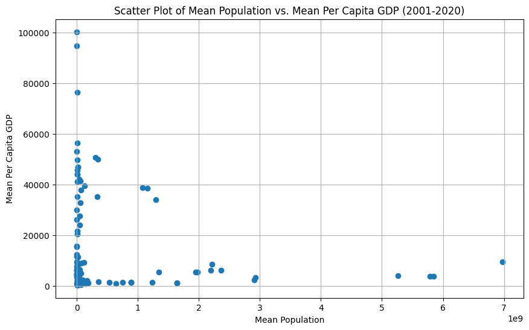

```python
import matplotlib.pyplot as plt

plt.figure(figsize=(10, 6))
plt.scatter(df_merged_means['mean_population'], df_merged_means['mean_per_capita_gdp'])
plt.title('Scatter Plot of Mean Population vs. Mean Per Capita GDP (2001-2020)')
plt.xlabel('Mean Population')
plt.ylabel('Mean Per Capita GDP')
plt.grid(True)
plt.show()
```

## Summarize findings

### Subtask:

Present the calculated correlation coefficient and discuss the relationship between population and per capita GDP based on the analysis.

**Reasoning**: State the calculated correlation coefficient, interpret its meaning, discuss the scatter plot, and mention limitations.

```python
print(f"The calculated correlation coefficient between mean population and mean per capita GDP is: {correlation_coefficient:.4f}")

print("\nInterpretation of the Correlation Coefficient:")
print(f"The correlation coefficient of {correlation_coefficient:.4f} indicates a very weak negative linear relationship between the mean population and mean per capita GDP for the countries in the dataset from 2001 to 2020.")
print("The negative sign suggests that as the mean population of a country increases, the mean per capita GDP tends to slightly decrease, but the value being close to zero (-0.1387) signifies that this relationship is extremely weak and not practically significant.")

print("\nObservations from the Scatter Plot:")
print("The scatter plot visually confirms the weak relationship. The data points are widely scattered with no clear strong linear pattern or trend. There isn't a discernible upward or downward sloping line that the points tend to follow closely. This lack of a tight clustering around any line is consistent with the low absolute value of the correlation coefficient.")

print("\nPotential Limitations of the Analysis:")
print("1. Correlation does not imply causation: This analysis only shows an association, not that one variable causes the other.")
print("2. Time period: The analysis is limited to the years 2001-2020. The relationship might be different over longer or different time periods.")
print("3. Aggregation: Using mean values across 20 years might mask year-to-year variations or significant changes within countries over time.")
print("4. Outliers: Extreme values in either population or GDP can influence the correlation coefficient.")
print("5. Other factors: Many other factors influence a country's per capita GDP besides its total population.")
```

```
The calculated correlation coefficient between mean population and mean per capita GDP is: -0.1387

Interpretation of the Correlation Coefficient:
The correlation coefficient of -0.1387 indicates a very weak negative linear relationship between the mean population and mean per capita GDP for the countries in the dataset from 2001 to 2020.
The negative sign suggests that as the mean population of a country increases, the mean per capita GDP tends to slightly decrease, but the value being close to zero (-0.1387) signifies that this relationship is extremely weak and not practically significant.

Observations from the Scatter Plot:
The scatter plot visually confirms the weak relationship. The data points are widely scattered with no clear strong linear pattern or trend. There isn't a discernible upward or downward sloping line that the points tend to follow closely. This lack of a tight clustering around any line is consistent…

Potential Limitations of the Analysis:
1. Correlation does not imply causation: This analysis only shows an association, not that one variable causes the other.
2. Time period: The analysis is limited to the years 2001-2020. The relationship might be different over longer or different time periods.
3. Aggregation: Using mean values across 20 years might mask year-to-year variations or significant changes within countries over time.
4. Outliers: Extreme values in either population or GDP can influence the correlation coefficient.
5. Other factors: Many other factors influence a country's per capita GDP besides its total population.
```

## Summary:

### Data Analysis Key Findings

- The analysis focused on the years 2001 to 2020 due to data availability, not 2001 to 2021 as initially planned.
- The calculated correlation coefficient between the mean population and mean per capita GDP for the period 2001-2020 is approximately -0.1387.
- This correlation coefficient indicates a very weak negative linear relationship between mean population and mean per capita GDP.
- The scatter plot visually confirms the weak relationship, showing widely scattered data points without a strong linear pattern.

### Insights or Next Steps

- The very weak negative correlation suggests that, for the period analyzed, a country's average population size is not a significant predictor of its average per capita GDP.
- Further analysis could explore non-linear relationships, analyze specific country groups (e.g., by income level or geographic region), or investigate the correlation over different time periods to see if the relationship changes.

**GDP is the total value of all goods and services produced in a country over a specific period. Per capita GDP takes that total value and spreads it out among everyone in the country. It's often used as an indicator of a country's standard of living and economic well-being, as it gives a rough idea of how much economic output is available per person. We are saying based on these results that a country's standard of living is not strongly related to the population size of a country - either negatively or positively**

## Perform Linear Regression

### Subtask:

Perform linear regression analysis with mean population as the independent variable and mean per capita GDP as the dependent variable.

**Reasoning**: Use `statsmodels.api` to perform ordinary least squares (OLS) regression. Define the independent and dependent variables, add a constant to the independent variable for the intercept, fit the model, and display the regression summary.

```python
import statsmodels.api as sm

# Define the independent variable (X) and the dependent variable (y)
X = df_merged_means['mean_population']
y = df_merged_means['mean_per_capita_gdp']

# Combine X and y into a single DataFrame to easily drop rows with NaNs in either column
data_for_regression = pd.DataFrame({'mean_population': X, 'mean_per_capita_gdp': y})

# Drop rows with NaN values in either column
data_for_regression_cleaned = data_for_regression.dropna()

# Redefine X and y from the cleaned DataFrame
X_cleaned = data_for_regression_cleaned['mean_population']
y_cleaned = data_for_regression_cleaned['mean_per_capita_gdp']


# Add a constant to the independent variable for the intercept
X_cleaned = sm.add_constant(X_cleaned)

# Create and fit the OLS model
model = sm.OLS(y_cleaned, X_cleaned).fit()

# Print the regression summary
print(model.summary())
```

```
                             OLS Regression Results
===============================================================================
Dep. Variable:     mean_per_capita_gdp   R-squared:                       0.019
Model:                             OLS   Adj. R-squared:                  0.011
Method:                  Least Squares   F-statistic:                     2.218
Date:                 Mon, 15 Sep 2025   Prob (F-statistic):              0.139
Time:                         19:31:40   Log-Likelihood:                -1302.3
No. Observations:                  115   AIC:                             2609.
Df Residuals:                      113   BIC:                             2614.
Df Model:                            1
Covariance Type:             nonrobust
===================================================================================
                      coef    std err          t      P>|t|      [0.025      0.975]
-----------------------------------------------------------------------------------
const            1.547e+04   2038.967      7.586      0.000    1.14e+04    1.95e+04
mean_population -2.296e-06   1.54e-06     -1.489      0.139   -5.35e-06    7.58e-07
==============================================================================
Omnibus:                       53.685   Durbin-Watson:                   1.980
Prob(Omnibus):                  0.000   Jarque-Bera (JB):              132.436
Skew:                           1.873   Prob(JB):                     1.75e-29
Kurtosis:                       6.690   Cond. No.                     1.43e+09
==============================================================================

Notes:
[1] Standard Errors assume that the covariance matrix of the errors is correctly specified.
[2] The condition number is large, 1.43e+09. This might indicate that there are
strong multicollinearity or other numerical problems.
```

## Perform Linear Regression using Scikit-learn

### Subtask:

Perform linear regression analysis using `scikit-learn` with mean population as the independent variable and mean per capita GDP as the dependent variable.

**Reasoning**: Import the `LinearRegression` model from `sklearn.linear_model`. Reshape the independent variable to be a 2D array as required by `sklearn` models. Create and fit the `LinearRegression` model, and then print the coefficient and intercept.

```python
from sklearn.linear_model import LinearRegression
import numpy as np
import pandas as pd # Import pandas

# Define the independent variable (X) and the dependent variable (y)
X = df_merged_means['mean_population']
y = df_merged_means['mean_per_capita_gdp']

# Combine X and y into a single DataFrame to easily drop rows with NaNs in either column
data_for_regression_sklearn = pd.DataFrame({'mean_population': X, 'mean_per_capita_gdp': y})

# Drop rows with NaN values in either column
data_for_regression_sklearn_cleaned = data_for_regression_sklearn.dropna()

# Redefine X and y from the cleaned DataFrame and reshape X for sklearn
X_cleaned_sklearn = data_for_regression_sklearn_cleaned['mean_population'].values.reshape(-1, 1)
y_cleaned_sklearn = data_for_regression_sklearn_cleaned['mean_per_capita_gdp'].values


# Create and fit the Linear Regression model
model_sklearn = LinearRegression()
model_sklearn.fit(X_cleaned_sklearn, y_cleaned_sklearn)

# Print the coefficient and intercept
print(f"Coefficient: {model_sklearn.coef_[0]:.4f}")
print(f"Intercept: {model_sklearn.intercept_:.4f}")
```

```
Coefficient: -0.0000
Intercept: 15466.8786
```

## Visualize Linear Regression

### Subtask:

Add the linear regression line from the scikit-learn model to the scatter plot of mean population vs. mean per capita GDP.

**Reasoning**: Use the `matplotlib.pyplot` library to create a scatter plot of the cleaned mean population and mean per capita GDP data. Then, use the fitted `sklearn` model to predict the per capita GDP values based on the mean population and plot the resulting regression line on the scatter plot.

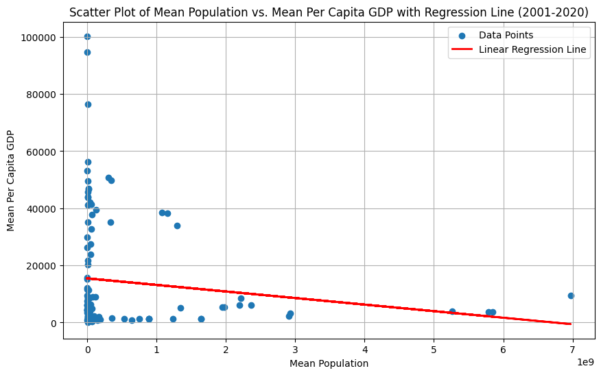

```python
import matplotlib.pyplot as plt
import numpy as np

# Use the cleaned data from the sklearn regression
X_plot = data_for_regression_sklearn_cleaned['mean_population']
y_plot = data_for_regression_sklearn_cleaned['mean_per_capita_gdp']

# Reshape X_plot for prediction
X_plot_reshaped = X_plot.values.reshape(-1, 1)

# Predict the per capita GDP values using the fitted sklearn model
y_pred = model_sklearn.predict(X_plot_reshaped)

# Create the scatter plot
plt.figure(figsize=(10, 6))
plt.scatter(X_plot, y_plot, label='Data Points')

# Plot the regression line
plt.plot(X_plot, y_pred, color='red', linewidth=2, label='Linear Regression Line')

plt.title('Scatter Plot of Mean Population vs. Mean Per Capita GDP with Regression Line (2001-2020)')
plt.xlabel('Mean Population')
plt.ylabel('Mean Per Capita GDP')
plt.grid(True)
plt.legend()
plt.show()
```